# p8105_hw1_to2345

Load library:

```r
library(tidyverse)
```

## Problem 1:

**Create a data frame comprised of:**

- a random sample of size 8 from a standard Normal distribution
- a logical vector indicating whether elements of the sample are greater than 0
- a character vector of length 8
- a factor vector of length 8, with 3 different factor “levels”

```r
set.seed(1)
dataframe_1 = tibble(
  random_sample = rnorm(8, sd = 1),
  vec_logic = random_sample > 0,
  vec_char = character(8),
  vec_factor = factor(c(1,2,2,3,1,2,3,3))
)
```

**Take the mean of each variables:**

1. The mean of the variable random_sample is 0.131.
2. The mean of the variable vec_logic is 0.625.
3. The mean of the variable vec_char is NA.
4. The mean of the variable vec_factor is NA.

*We can see that the means of the created randome sample and the logic vector works. Yet, the means of the character vector and the factor vector does not work.*

**Convert the logical vector to other data types, and multiply the random sample**

- convert the logical vector to numeric, and multiply the random sample by the result
- convert the logical vector to a factor, and multiply the random sample by the result
- convert the logical vector to a factor and then convert the result to numeric, and multiply the random sample by the result

```r
log_to_num = as.numeric(pull(dataframe_1, vec_logic))
log_to_factor = as.factor(pull(dataframe_1, vec_logic))
factor_to_num = as.numeric(as.factor(pull(dataframe_1, vec_logic)))
```

1. The result of multiply the random sample by the new numeric vector is 0, 0.184, 0, 1.595, 0.33, 0, 0.487, 0.738.
2. The result of multiply the random sample by the new factor is NA, NA, NA, NA, NA, NA, NA, NA.
3. The result of multiply the random sample by the new numeric vector which is converted from a factor is -0.626, 0.367, -0.836, 3.191, 0.659, -0.82, 0.975, 1.477.

## Problem 2:

**Create a data frame comprised of:** x: a random sample of size 500 from a standard Normal distribution y: a random sample of size 500 from a standard Normal distribution A logical vector indicating whether x + y > 1 A numeric vector created by coercing the above logical vector A factor vector created by coercing the above logical vector

**create a new dataframe:**

```r
dataframe_2 = tibble(
  x = rnorm(500, mean = 0, sd = 1),
  y = rnorm(500, mean = 0, sd = 1),
  vec_logic = (x+y) > 1,
  vec_num = as.numeric(vec_logic),
  vec_factor = as.factor(vec_logic)
)
```

**Some description for this dataset**:

```
1. The size of the dataset is 500 by 5
2. The mean, median, and standard deviation of x is 0.02, -0.038, and 1.014 respectively.
3. The proportion of cases for which x + y > 1 is 25.2%
```

**Make a scatterplot of y vs x, color points using the logical variable**

```r
plot_1 = ggplot(dataframe_2, aes(x = x, y = y, color = vec_logic)) + geom_point()
```

**Export this scatterplot using ggsave**

```r
ggsave("plot_hw1.png", plot = plot_1)
```

**Make a scatterplot of y vs x, color points using the numeric variable**

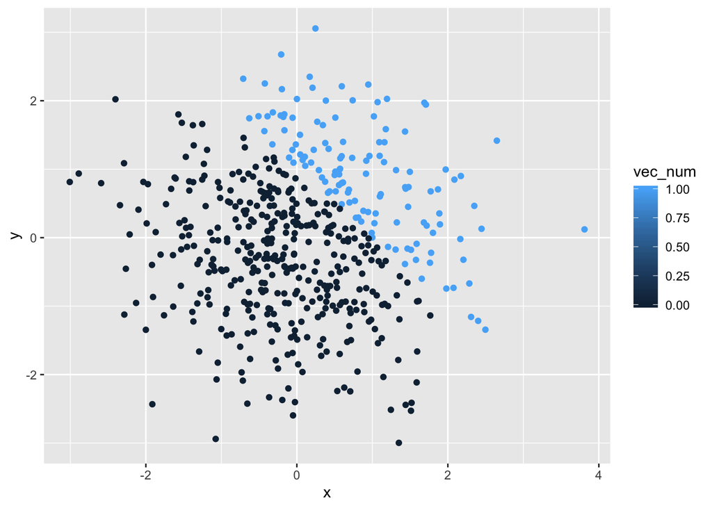

```r
ggplot(dataframe_2, aes(x = x, y = y, color = vec_num)) + geom_point()
```

**Make a scatterplot of y vs x, color points using the factor variable**

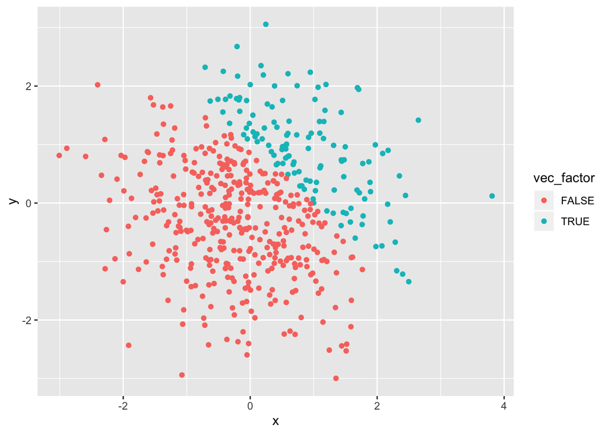

```r
ggplot(dataframe_2, aes(x = x, y = y, color = vec_factor)) + geom_point()
```